# Homework 02

## Question 1: Training and test error under a fixed design

Consider a linear regression problem with $n=100$ observations and $q=20$ available covariates. Generate one matrix $\mathbf X_{\mathrm{all}}\in\mathbb R^{n\times q}$ whose entries are independent $\mathcal N(0,1)$ random variables, and then keep this realized matrix fixed. Let

$$\beta_k=0.4^{\sqrt{k}},
\qquad k=1,\ldots,q,$$

and define

$$\boldsymbol\mu=\mathbf X_{\mathrm{all}}\boldsymbol\beta.$$

Generate one training response and one independent test response from

$$\begin{aligned}
\mathbf y
&=\boldsymbol\mu+\boldsymbol\epsilon,\\
\mathbf y^*
&=\boldsymbol\mu+\boldsymbol\epsilon^*,
\end{aligned}$$

where

$$\boldsymbol\epsilon,\boldsymbol\epsilon^*
\overset{\mathrm{ind}}{\sim}
\mathcal N_n(\mathbf 0,\mathbf I_n).$$

Here $\mathbf I_n$ is the $n\times n$ identity matrix.

For $j=0,1,\ldots,q$, fit a linear model with an intercept and the first $j$ columns of $\mathbf X_{\mathrm{all}}$ using $\mathbf y$. If $\widehat{\boldsymbol\mu}_j$ is its fitted mean vector, define

$$\operatorname{MSE}_{\mathrm{train},j}
=\frac{1}{n}
\left\lVert
\mathbf y-\widehat{\boldsymbol\mu}_j
\right\rVert_2^2,$$

and

$$\operatorname{MSE}_{\mathrm{test},j}
=\frac{1}{n}
\left\lVert
\mathbf y^*-\widehat{\boldsymbol\mu}_j
\right\rVert_2^2.$$

Repeat this process independently 200 times, keeping $\mathbf X_{\mathrm{all}}$ fixed.

Use seed `43202` before generating $\mathbf X_{\mathrm{all}}$ and the response errors. R and Python use different random-number generators, so their exact numerical values need not agree.

1. For each $j$, calculate the average training and test MSE over the 200 simulation runs. Plot both curves against $j$. Verify numerically that training MSE does not increase as predictors are added in each simulation run.

**Show the starter code**

```r
set.seed(43202)
n <- 100
p <- 20
simulationruns <- 200

Xall <- matrix(rnorm(n * p), nrow=n)
beta <- 0.4^sqrt(1:p)
mu <- drop(Xall %*% beta)

msetrain <- matrix(NA, nrow = simulationruns, ncol = p + 1)
msetest <- matrix(NA, nrow = simulationruns, ncol = p + 1)

test_one_run <- numeric(p + 1)

for (s in 1:simulationruns) {

  epsilon <- rnorm(n)
  epsilon_star <- rnorm(n)

  y <- mu + epsilon
  y_star <- mu + epsilon_star

  for (j in 0:p) {

    if (j == 0) {
      Xj <- matrix(1, nrow = n, ncol = 1)
    } else {
      Xj <- cbind(1, Xall[, 1:j])
    }

    beta_hat <- solve(t(Xj) %*% Xj) %*% t(Xj) %*% y
    y_hat <- Xj %*% beta_hat

    msetrain[s, j + 1] <- mean((y - y_hat)^2)
    msetest[s, j + 1] <- mean((y_star - y_hat)^2)
  }

  if (s == 1) {
    test_one_run <- msetest[s, ]
  }
}

avg_trainmse <- colMeans(msetrain)
avg_testmse <- colMeans(msetest)
j_values <- 0:p
training_differences <- apply(msetrain, 1, diff)
all_training_nonincreasing <- all(training_differences <= 1e-10)
all_training_nonincreasing
```

```
[1] TRUE
```

**Show the starter code**

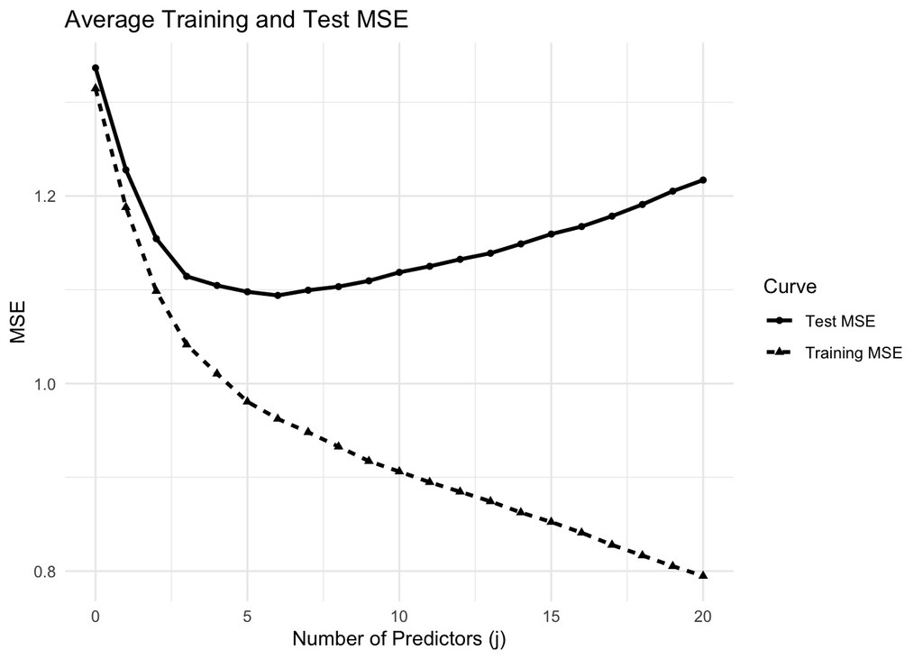

```r
library(ggplot2)
mseresults <- data.frame(
  j = j_values,
  Train = avg_trainmse,
  Test = avg_testmse
)

ggplot(mseresults, aes(x = j)) +
  geom_line(aes(y = Train, linetype = "Training MSE"), linewidth = 1) +
  geom_point(aes(y = Train, shape = "Training MSE")) +
  geom_line(aes(y = Test, linetype = "Test MSE"), linewidth = 1) +
  geom_point(aes(y = Test, shape = "Test MSE")) +
  labs(
    x = "Number of Predictors (j)",
    y = "MSE",
    linetype = "Curve",
    shape = "Curve",
    title = "Average Training and Test MSE"
  ) +
  theme_minimal()
```

2. For the model containing the first $j$ predictors, write

$$\mathbf X_j
=
[\mathbf 1,\mathbf x_1,\ldots,\mathbf x_j],
\qquad
\mathbf H_j
=
\mathbf X_j
(\mathbf X_j^{\mathsf T}\mathbf X_j)^{-1}
\mathbf X_j^{\mathsf T}.$$

Let $p_j=j+1$ be its fitted mean-parameter count, including the intercept. Define its **total squared approximation bias** as

$$B_j^2
=\left\lVert
(\mathbf I_n-\mathbf H_j)\boldsymbol\mu
\right\rVert_2^2.$$

Thus, $B_j^2/n$ is the mean squared approximation bias.

Calculate the two theoretical expectations

$$E\!\left(
\operatorname{MSE}_{\mathrm{train},j}
\mid \mathbf X_{\mathrm{all}}
\right)
=\frac{B_j^2}{n}+1-\frac{p_j}{n},$$

and

$$E\!\left(
\operatorname{MSE}_{\mathrm{test},j}
\mid \mathbf X_{\mathrm{all}}
\right)
=\frac{B_j^2}{n}+1+\frac{p_j}{n}.$$

Add these expectations to your plot and compare them with the simulation averages.

**Show the starter code**

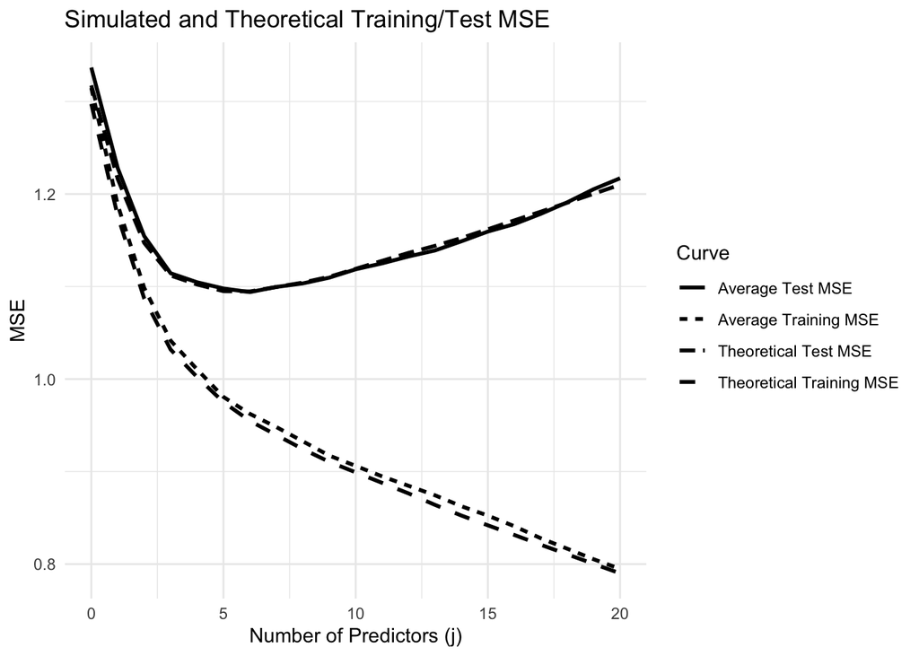

```r
train_theory <- numeric(p + 1)
test_theory <- numeric(p + 1)
bias_squared <- numeric(p + 1)

for (j in 0:p) {

  if (j == 0) {
    Xj <- matrix(1, nrow = n, ncol = 1)
  } else {
    Xj <- cbind(1, Xall[, 1:j])
  }

  H_j <- Xj %*% solve(t(Xj) %*% Xj) %*% t(Xj)

  bias_squared[j + 1] <- sum(((diag(n) - H_j) %*% mu)^2)

  p_j <- j + 1

  train_theory[j + 1] <- bias_squared[j + 1] / n +
    1 - p_j / n

  test_theory[j + 1] <- bias_squared[j + 1] / n +
    1 + p_j / n
}

mse_results <- data.frame(
  j = j_values,
  Train = avg_trainmse,
  Test = avg_testmse,
  Theory_Train = train_theory,
  Theory_Test = test_theory
)

ggplot(mse_results, aes(x = j)) +
  geom_line(aes(y = Train, linetype = "Average Training MSE"), linewidth = 1) +
  geom_line(aes(y = Test, linetype = "Average Test MSE"), linewidth = 1) +
  geom_line(aes(y = Theory_Train, linetype = "Theoretical Training MSE"),
            linewidth = 1) +
  geom_line(aes(y = Theory_Test, linetype = "Theoretical Test MSE"),
            linewidth = 1) +
  labs(
    x = "Number of Predictors (j)",
    y = "MSE",
    linetype = "Curve",
    title = "Simulated and Theoretical Training/Test MSE"
  ) +
  theme_minimal()
```

3. Add the test MSE curve from one simulation run to the plot. Explain why this single curve is less smooth than the average test MSE. Use the approximation-bias and estimation-variance terms in the expected test MSE to explain why training MSE cannot be used by itself to select the predictor count.

**Show the starter code**

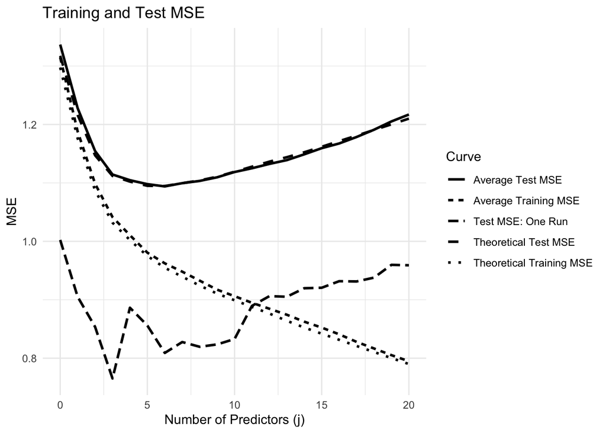

```r
ggplot(mse_results, aes(x = j)) +
  geom_line(aes(y = Train, linetype = "Average Training MSE"), linewidth = 1) +
  geom_line(aes(y = Test, linetype = "Average Test MSE"), linewidth = 1) +
  geom_line(aes(y = Theory_Train, linetype = "Theoretical Training MSE"),
            linewidth = 1) +
  geom_line(aes(y = Theory_Test, linetype = "Theoretical Test MSE"),
            linewidth = 1) +
  geom_line(aes(y = test_one_run, linetype = "Test MSE: One Run"),
            linewidth = 1) +
  labs(
    x = "Number of Predictors (j)",
    y = "MSE",
    linetype = "Curve",
    title = "Training and Test MSE"
  ) +
  theme_minimal()
```

**Show the starter code**

```r
#The single-run test MSE is affected by random variation from  one training and test sample. Averaging over 200 simulations makes the curve smoother. When adding predictors approximation bias decreases, but estimation variance increases. Training MSE  reflects the fit to the training data so it keeps decreasing.
```

## Question 2: Prediction error at one target point

Let $n=100$, $q=6$, and $\sigma^2=1$. Construct the fixed covariate matrix $\mathbf X_{\mathrm{all}}\in\mathbb R^{n\times q}$ with entries

$$(\mathbf X_{\mathrm{all}})_{ik}
=\sqrt{2}\cos\left\{
\frac{\pi k(i-\tfrac12)}{n}
\right\},
\qquad
i=1,\ldots,n,
\quad
k=1,\ldots,q.$$

Its columns satisfy

$$\mathbf 1^{\mathsf T}\mathbf X_{\mathrm{all}}=\mathbf 0^{\mathsf T},
\qquad
\frac{1}{n}\mathbf X_{\mathrm{all}}^{\mathsf T}\mathbf X_{\mathrm{all}}=\mathbf I_q.$$

Here $\mathbf I_q$ is the $q\times q$ identity matrix.

The following code shows a direct construction of $\mathbf X_{\mathrm{all}}$.

**R**

**Show the starter code**

```r
n <- 100
q <- 6
X_all <- outer(
  1:n, 1:q,
  function(i, k) sqrt(2) * cos(pi * k * (i - 0.5) / n)
)
```

Keep $\mathbf X_{\mathrm{all}}$ fixed and generate one training response from

$$\mathbf y
=\mathbf X_{\mathrm{all}}\boldsymbol\beta+\boldsymbol\epsilon,
\qquad
\boldsymbol\beta
=(0.5,0.5,0.5,0.5,0.5,0.5)^{\mathsf T},$$

where

$$\boldsymbol\epsilon
\sim
\mathcal N_n(\mathbf 0,\mathbf I_n).$$

Here $\mathbf I_n$ is the $n\times n$ identity matrix.

For $j=0,\ldots,6$, fit a linear model with an intercept and the first $j$ predictors. Consider prediction of the mean response at

$$\mathbf x_0=(0,1,0,0,1,0)^{\mathsf T}.$$

Write

$$\mu_0=\mathbf x_0^{\mathsf T}\boldsymbol\beta,$$

and let $\widehat\mu_{0,j}$ be the prediction from the model containing the first $j$ predictors. Here $x_{0k}$ denotes the $k$th coordinate of $\mathbf x_0$. For this design,

$$E\!\left[
\left(\widehat\mu_{0,j}-\mu_0\right)^2
\mid \mathbf X_{\mathrm{all}}
\right]
=
\left(
\sum_{k=j+1}^{q}x_{0k}\beta_k
\right)^2
+\frac{\sigma^2}{n}
\left(
1+\sum_{k=1}^{j}x_{0k}^2
\right).$$

1. Calculate $\mu_0$ and the theoretical expected squared error for $j=0,\ldots,6$. Identify the values of $j$ where this error changes and where it remains unchanged.

**Show the starter code**

```r
n <- 100
q <- 6
sigma2 <- 1
X_all <- outer(
  1:n, 1:q,
  function(i, k) sqrt(2) * cos(pi * k * (i - 0.5) / n)
)
beta <- rep(0.5, q)
x0 <- c(0, 1, 0, 0, 1, 0)
mu0 <- sum(x0 * beta)
theoreticalerror <- numeric(q + 1)
for (j in 0:q) {

  if (j < q) {
    bias <- sum(x0[(j + 1):q] * beta[(j + 1):q])
  } else {
    bias <- 0
  }
    if (j > 0) {
    variance <- sigma2 / n * (1 + sum(x0[1:j]^2))
  } else {
    variance <- sigma2 / n
  }
  theoreticalerror[j + 1] <- bias^2 + variance
}

data.frame(
  j = 0:q,
  theoreticalerror = theoreticalerror
)
```

```
  j theoreticalerror
1 0             1.01
2 1             1.01
3 2             0.27
4 3             0.27
5 4             0.27
6 5             0.03
7 6             0.03
```

2. Use seed `43203`. Generate the response, fit the models, and calculate

$$\left(\widehat\mu_{0,j}-\mu_0\right)^2.$$

Repeat this independently 200 times. Plot the simulation averages and theoretical expectations together. Report the smallest $j$ that minimizes the theoretical error.

**Show the starter code**

```r
set.seed(43203)
simulationruns <- 200
squarederrors <- matrix(
  NA,
  nrow = simulationruns,
  ncol = q + 1
)
for (s in 1:simulationruns) {
    epsilon <- rnorm(n)
  y <- X_all %*% beta + epsilon
  for (j in 0:q) {
    if (j == 0) {
      Xj <- matrix(1, nrow = n, ncol = 1)
    } else {
      Xj <- cbind(1, X_all[, 1:j])
    }
    betahat <- solve(t(Xj) %*% Xj) %*% t(Xj) %*% y
        if (j == 0) {
      x0j <- 1
    } else {
      x0j <- c(1, x0[1:j])
    }
    muhat <- sum(x0j * betahat)
        squarederrors[s, j + 1] <- (muhat - mu0)^2
  }
}
averageerror <- colMeans(squarederrors)

results <- data.frame(
  j = 0:q,
  simulationaverage = averageerror,
  theoretical = theoreticalerror
)
results
```

```
  j simulationaverage theoretical
1 0        1.01891864        1.01
2 1        1.01891864        1.01
3 2        0.26711699        0.27
4 3        0.26711699        0.27
5 4        0.26711699        0.27
6 5        0.03375873        0.03
7 6        0.03375873        0.03
```

**Show the starter code**

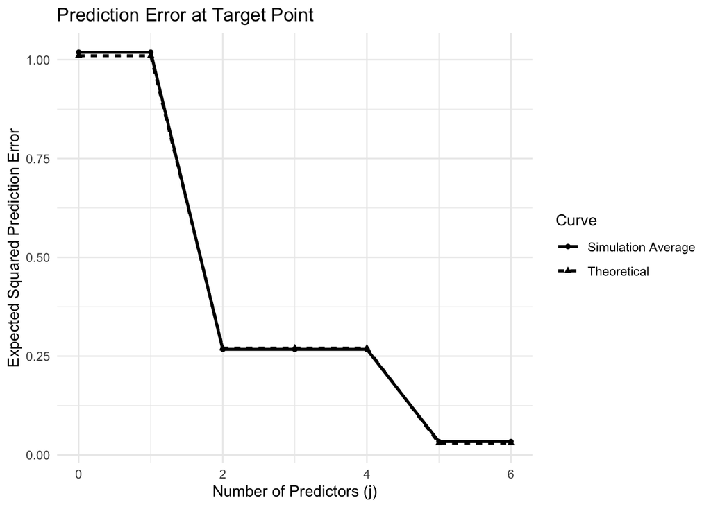

```r
library(ggplot2)

ggplot(results, aes(x = j)) +
  geom_line(aes(y = simulationaverage,
                linetype = "Simulation Average"),
            linewidth = 1) +
  geom_point(aes(y = simulationaverage,
                 shape = "Simulation Average")) +
  geom_line(aes(y = theoretical,
                linetype = "Theoretical"),
            linewidth = 1) +
  geom_point(aes(y = theoretical,
                 shape = "Theoretical")) +
  labs(
    x = "Number of Predictors (j)",
    y = "Expected Squared Prediction Error",
    linetype = "Curve",
    shape = "Curve",
    title = "Prediction Error at Target Point"
  ) +
  theme_minimal()
```

3. All six regression coefficients are nonzero. Explain why only predictors 2 and 5 contribute directly to the mean response at $\mathbf x_0$. Contrast this target-specific error with the test MSE averaged over all rows of $\mathbf X_{\mathrm{all}}$ in Question 1.

Only predictors 2 and 5 affect the target mean. This target-specific error differs from the test MSE in Question 1 since Question 1 averages prediction error over target points. This question evaluates error at one specific target point.

## Question 3: The optimism correction

Choose one candidate model before observing the response. Let $\mathbf X\in\mathbb R^{n\times p}$ be its full-rank design matrix, including the intercept, and let

$$\mathbf H
=\mathbf X
(\mathbf X^{\mathsf T}\mathbf X)^{-1}
\mathbf X^{\mathsf T}$$

be its hat matrix. Suppose

$$\mathbf y=\boldsymbol\mu+\boldsymbol\epsilon,
\qquad
\mathbf y^*=\boldsymbol\mu+\boldsymbol\epsilon^*,$$

Conditional on the fixed design $\mathbf X$, the two error vectors are independent, have mean zero, and have covariance matrix $\sigma^2\mathbf I_n$. Define

$$\operatorname{MSE}_{\mathrm{train}}
=
\frac{1}{n}
\left\lVert
\mathbf y-\mathbf H\mathbf y
\right\rVert_2^2,
\qquad
\operatorname{MSE}_{\mathrm{test}}
=
\frac{1}{n}
\left\lVert
\mathbf y^*-\mathbf H\mathbf y
\right\rVert_2^2.$$

The conditional bias vector of the fitted mean is

$$E(\mathbf H\mathbf y\mid\mathbf X)-\boldsymbol\mu
=
-(\mathbf I_n-\mathbf H)\boldsymbol\mu.$$

Let $B^2$ denote the **total squared approximation bias**:

$$B^2
=\left\lVert
(\mathbf I_n-\mathbf H)\boldsymbol\mu
\right\rVert_2^2.$$

Thus, $B^2/n$ is the mean squared approximation bias.

You may use

$$\mathbf H^{\mathsf T}=\mathbf H,
\qquad
\mathbf H^2=\mathbf H,
\qquad
\operatorname{tr}(\mathbf H)=p.$$

For any fixed matrix $\mathbf A$, you may also use

$$E\!\left(
\boldsymbol\epsilon^{\mathsf T}
\mathbf A
\boldsymbol\epsilon
\mid \mathbf X
\right)
=\sigma^2\operatorname{tr}(\mathbf A).$$

1. Derive

$$E(\operatorname{MSE}_{\mathrm{train}}\mid\mathbf X)
=\frac{B^2}{n}
+\sigma^2\left(1-\frac{p}{n}\right),$$

and

$$E(\operatorname{MSE}_{\mathrm{test}}\mid\mathbf X)
=\frac{B^2}{n}
+\sigma^2\left(1+\frac{p}{n}\right).$$

**Show the starter code**

```r
n <- 120
p <- 5
sigma2 <- 1
B2_over_n <- 0.04
expectedtrain <- B2_over_n + sigma2 * (1 - p/n)
expectedtest <- B2_over_n + sigma2 * (1 + p/n)
expectedtrain
```

```
[1] 0.9983333
```

**Show the starter code**

```r
expectedtest
```

```
[1] 1.081667
```

2. Deduce the expected optimism, defined as $E(\operatorname{MSE}_{\mathrm{test}}-\operatorname{MSE}_{\mathrm{train}}\mid\mathbf X)$. For

$$n=120,
\qquad
p=5,
\qquad
\frac{B^2}{n}=0.04,
\qquad
\sigma^2=1,$$

calculate the expected training MSE, expected test MSE, and their difference. Explain why the ordering need not hold for every realized pair of responses.

**Show the starter code**

```r
n <- 120
p <- 5
B2_over_n <- 0.04
sigma2 <- 1
expectedtrain <- B2_over_n + sigma2 * (1 - p/n)
expectedtest <- B2_over_n + sigma2 * (1 + p/n)
expectedoptimism <- expectedtest - expectedtrain
data.frame(
  Expected_Training_MSE = expectedtrain,
  Expected_Test_MSE = expectedtest,
  Expected_Optimism = expectedoptimism
)
```

```
  Expected_Training_MSE Expected_Test_MSE Expected_Optimism
1             0.9983333          1.081667        0.08333333
```

**Show the starter code**

```r
#The expected training MSE is 0.998, the expected test MSE is 1.081, and the expected optimism is 0.0833. The realized MSEs contain random variation.
```

3. Continue with $n=120$ and $p=5$. Suppose the candidate model has residual sum of squares $\operatorname{RSS}=116.4$, and suppose a common estimate of the error variance is $\widehat\sigma^2=0.96$.

Calculate

$$\widehat{\operatorname{MSE}}_{\mathrm{test}}
=\frac{
\operatorname{RSS}+2p\widehat\sigma^2
}{n},$$

and

$$C_p
=\frac{\operatorname{RSS}}{\widehat\sigma^2}
-n+2p.$$

Show how these two quantities are related, and explain why minimizing $C_p$ is equivalent to minimizing the corrected test MSE when $n$ and $\widehat\sigma^2$ are common to all candidate models.

**Show the starter code**

```r
n <- 120
p <- 5
RSS <- 116.4
sigma2_hat <- 0.96
MSEtest_hat <- (RSS + 2 * p * sigma2_hat) / n
Cp <- RSS / sigma2_hat - n + 2 * p
MSEfrom_Cp <- sigma2_hat * (1 + Cp / n)

data.frame(
  CorrectedTest_MSE = MSEtest_hat,
  Cp = Cp,
  MSEfrom_Cp = MSEfrom_Cp
)
```

```
  CorrectedTest_MSE    Cp MSEfrom_Cp
1              1.05 11.25       1.05
```

## Question 4: Comparing Mallows’ $C_p$, AIC, and BIC

Use `data/diabetes.csv`, with `y` as the response. Use rows 1 through 370 as the training data, and let $n=370$ denote the training sample size. Do not use rows 371 through 442 in this question. Fit the following ordinary least-squares models, each with an intercept.

| Model | Predictors | $p$ |
| --- | --- | --- |
| Model A | `bmi`, `bp`, `s5`, `sex`, `s1`, `s2`, `s4` | 8 |
| Model B | all predictors in Model A, followed by `s6` | 9 |
| Full reference | all ten predictors | 11 |

Here $p$ counts fitted mean parameters, including the intercept. Estimate one common noise variance from the full reference model:

$$\widehat\sigma^2_{\mathrm{full}}
=\frac{\operatorname{RSS}_{\mathrm{full}}}{n-11}.$$

For Models A and B, calculate

$$C_p
=\frac{\operatorname{RSS}}{\widehat\sigma^2_{\mathrm{full}}}
-n+2p,$$

$$\operatorname{AIC}^{\mathrm{red}}
=n\log\left(\frac{\operatorname{RSS}}{n}\right)+2p,$$

and

$$\operatorname{BIC}^{\mathrm{red}}
=n\log\left(\frac{\operatorname{RSS}}{n}\right)
+p\log(n).$$

The reduced AIC and BIC omit constants shared by the two candidate models. Smaller values are preferred within each criterion.

1. Fit the three models. Report $p$, RSS, the residual degrees of freedom of the full model, and $\widehat\sigma^2_{\mathrm{full}}$.

**Show the starter code**

```r
diabetes <- read.csv("data/diabetes.csv")
train <- diabetes[1:370, ]
n <- 370
modelA <- lm(
  y ~ bmi + bp + s5 + sex + s1 + s2 + s4,
  data = train
)
modelB <- lm(
  y ~ bmi + bp + s5 + sex + s1 + s2 + s4 + s6,
  data = train
)
fullmodel <- lm(
  y ~ age + sex + bmi + bp + s1 + s2 + s3 + s4 + s5 + s6,
  data = train
)

RSSA <- sum(resid(modelA)^2)
RSSB <- sum(resid(modelB)^2)
RSSfull <- sum(resid(fullmodel)^2)

dffull <- df.residual(fullmodel)

sigma2_full <- RSSfull / dffull

data.frame(
  Model = c("Model A", "Model B", "Full Reference"),
  p = c(8, 9, 11),
  RSS = c(RSSA, RSSB, RSSfull),
  ResidualDF = c(df.residual(modelA),
                  df.residual(modelB),
                  df.residual(fullmodel))
)
```

```
           Model  p     RSS ResidualDF
1        Model A  8 1098909        362
2        Model B  9 1089717        361
3 Full Reference 11 1089452        359
```

**Show the starter code**

```r
sigma2_full
```

```
[1] 3034.684
```

2. Calculate $C_p$, reduced AIC, and reduced BIC for Models A and B. State which model each criterion selects. Do not compare numerical values across different criteria.

**Show the starter code**

```r
CpA <- RSSA / sigma2_full - n + 2 * 8
AICredA <- n * log(RSSA / n) + 2 * 8
BICredA <- n * log(RSSA / n) + 8 * log(n)
CpB <- RSSB / sigma2_full - n + 2 * 9

AICredB <- n * log(RSSB / n) + 2 * 9

BICredB <- n * log(RSSB / n) + 9 * log(n)

criteria <- data.frame(
  Model = c("Model A", "Model B"),
  Cp = c(CpA, CpB),
  AIC_reduced = c(AICredA, AICredB),
  BIC_reduced = c(BICredA, BICredB)
)
criteria
```

```
    Model       Cp AIC_reduced BIC_reduced
1 Model A 8.116253    2974.640    3005.948
2 Model B 7.087434    2973.532    3008.754
```

3. Compare the improvement in fit from adding `s6` with the one-parameter penalty under each criterion. Use this comparison to explain any disagreement. Why does selecting a model not establish that it is the true data-generating model?

**Show the starter code**

```r
RSSimprove <- RSSA - RSSB
Cppenalty <- 2 * sigma2_full
AICpenalty <- 2
BICpenalty <- log(n)
data.frame(
  Quantity = c(
    "RSS improvement  adding s6",
    "Cp penalty",
    "AIC penalty",
    "BIC penalty"
  ),
  Value = c(
    RSSimprove,
    Cppenalty,
    AICpenalty,
    BICpenalty
  )
)
```

```
                    Quantity       Value
1 RSS improvement  adding s6 9191.508850
2                 Cp penalty 6069.368920
3                AIC penalty    2.000000
4                BIC penalty    5.913503
```

**Show the starter code**

```r
#Adding s6 reduces the RSS from 1,098,908 for Model A to 1,089,717 for Model B. The disagreement occurs because BIC applies a larger penalty for adding one parameter compared with AIC's penalty of 2. BIC favors the simpler model more strongly. These criteria do not prove that the selected set of predictors is the true underlying model.
```

## Question 5: Validation and final test data

Use rows 1 through 370 of `diabetes.csv` as the training data and rows 371 through 442 as the final test data. Consider eleven nested candidate models. For $j=0,1,\ldots,10$, the model with $j$ predictors contains an intercept and the first $j$ predictors in this order:

`age`, `sex`, `bmi`, `bp`, `s1`, `s2`, `s3`, `s4`, `s5`, `s6`.

An analyst proposes the following procedure:

1. Fit all eleven candidate models using the training data.
2. Calculate the MSE of each model on the final test data.
3. Select the model with the smallest test MSE.
4. Report that minimum as the final estimate of prediction error.

The analyst argues that the procedure is valid because the final test data were not used to estimate the regression coefficients.

1. Identify the first step that misuses the final test data. Explain why the minimum of eleven test MSE values is generally too favorable as an estimate of the selected procedure’s future prediction error.

**Show the starter code**

```r
diabetes <- read.csv("data/diabetes.csv")
train <- diabetes[1:370, ]
finaltest <- diabetes[371:442, ]
ntrain <- nrow(train)
ntest <- nrow(finaltest)
predictors <- c(
  "age", "sex", "bmi", "bp", "s1",
  "s2", "s3", "s4", "s5", "s6"
)
testmse <- numeric(11)
for (j in 0:10) {
  if (j == 0) {
    model <- lm(y ~ 1, data = train)
  } else {
    formula_j <- as.formula(
      paste("y ~", paste(predictors[1:j], collapse = " + "))
    )
    model <- lm(formula_j, data = train)
  }
  predictions <- predict(model, newdata = finaltest)

  testmse[j + 1] <- mean(
    (finaltest$y - predictions)^2
  )
}
wrongresults <- data.frame(
  j = 0:10,
  TestMSE = testmse
)
wrongresults
```

```
    j  TestMSE
1   0 5822.890
2   1 5527.791
3   2 5527.210
4   3 3719.235
5   4 3246.823
6   5 3234.919
7   6 3207.615
8   7 2636.502
9   8 2624.924
10  9 2369.344
11 10 2484.776
```

**Show the starter code**

```r
which.min(testmse) - 1
```

```
[1] 9
```

**Show the starter code**

```r
min(testmse)
```

```
[1] 2369.344
```

2. Rewrite the analysis using five-fold cross-validation within the training data. State how the predictor count is selected, what is refitted, and when the final test data may be used.

**Show the starter code**

```r
set.seed(43205)
K <- 5

folds <- sample(rep(1:K, length.out = ntrain))

cvmse <- matrix(
  NA,
  nrow = K,
  ncol = 11
)

for (k in 1:K) {
  foldtrain <- train[folds != k, ]
  foldvalid <- train[folds == k, ]

  for (j in 0:10) {
    if (j == 0) {
      model <- lm(y ~ 1, data = foldtrain)
    } else {
      formula_j <- as.formula(
        paste("y ~", paste(predictors[1:j], collapse = " + "))
      )
      model <- lm(formula_j, data = foldtrain)
    }

    predictions <- predict(model, newdata = foldvalid)

    cvmse[k, j + 1] <- mean(
      (foldvalid$y - predictions)^2
    )
  }
}

cvresults <- data.frame(
  j = 0:10,
  CVMSE = colMeans(cvmse)
)

cvresults
```

```
    j    CVMSE
1   0 5960.940
2   1 5809.291
3   2 5858.935
4   3 3989.397
5   4 3748.975
6   5 3789.129
7   6 3799.011
8   7 3198.290
9   8 3214.378
10  9 3104.117
11 10 3132.714
```

**Show the starter code**

```r
# Select the number of predictors with the smallest CV MSE
best_j <- which.min(cvresults$CVMSE) - 1

best_j
```

```
[1] 9
```

**Show the starter code**

```r
# Refit the selected model using all training observations
if (best_j == 0) {
  finalmodel <- lm(y ~ 1, data = train)
} else {
  finalformula <- as.formula(
    paste("y ~", paste(predictors[1:best_j], collapse = " + "))
  )
  finalmodel <- lm(finalformula, data = train)
}

summary(finalmodel)
```

```
Call:
lm(formula = finalformula, data = train)

Residuals:
     Min       1Q   Median       3Q      Max
-156.627  -40.331   -4.128   40.006  153.609

Coefficients:
            Estimate Std. Error t value Pr(>|t|)
(Intercept)  152.710      2.873  53.160  < 2e-16 ***
age           30.092     65.058   0.463 0.643977
sex         -247.617     67.867  -3.649 0.000303 ***
bmi          541.488     74.211   7.297 1.90e-12 ***
bp           321.258     72.294   4.444 1.18e-05 ***
s1          -664.052    472.762  -1.405 0.160996
s2           378.639    386.905   0.979 0.328418
s3            41.569    241.074   0.172 0.863193
s4           161.852    177.102   0.914 0.361387
s5           703.159    192.259   3.657 0.000293 ***
---
Signif. codes:  0 '***' 0.001 '**' 0.01 '*' 0.05 '.' 0.1 ' ' 1

Residual standard error: 55.23 on 360 degrees of freedom
Multiple R-squared:  0.5014,    Adjusted R-squared:  0.4889
F-statistic: 40.22 on 9 and 360 DF,  p-value: < 2.2e-16
```

**Show the starter code**

```r
finalpredictions <- predict(
  finalmodel,
  newdata = finaltest
)

finaltest_mse <- mean(
  (finaltest$y - finalpredictions)^2
)

finaltest_mse
```

```
[1] 2369.344
```

3. Suppose the analyst has already examined all eleven test MSE values. What can still be reported transparently, and what additional data would be needed for a new final evaluation?

The test MSE values can still be reported transparently, including the test MSE for each model and which model had the smallest value. A new, independent test dataset would be needed for a new final evaluation.

## Reference

James, Witten, Hastie, Tibshirani, and Taylor, [*An Introduction to Statistical Learning*](https://www.statlearning.com/), Chapters 3, 5, and 6.